# BUSN 41201 Final Project

Arthur Cheib, Yu-Wei Chen, Simone Zhang, Sheng-Hau Peng, Shu-Hsiang Wang

2023-05-30

# Contents

- Summary
- Introduction
- Dataset Information
  - Source
  - Data Set Information
  - Attribute Information
- Exploratory Data Analysis
  - Data Cleaning
  - Data Visualization
- Questions that We Want to Solve
- Model Building
  - Regression
    - Logistics Regression on Default
    - LASSO
    - AIC
    - Principle Components Analysis
    - Compare the Result
  - Clustering
    - K Means
    - Hierarchical Clustering
  - Machine Learning
    - Decision Trees
    - Random Forest
    - Classification And Regression Trees (CART)
    - Neural Network
- Conclusion
- Potential Future Research
- Appendix

# Summary

# Introduction

# Dataset Information

## Source:

Name: I-Cheng Yeh

Email addresses: (1) icyeh ‘@’ chu.edu.tw (2) 140910 ‘@’ mail.tku.edu.tw

Institutions: (1) Department of Information Management, Chung Hua University, Taiwan. (2) Department of Civil Engineering, Tamkang University, Taiwan. Other contact information: 886-2-26215656 ext. 3181

## Data Set Information:

This research aimed at the case of customers default payments in Taiwan and compares the predictive accuracy of probability of default among six data mining methods. From the perspective of risk management, the result of predictive accuracy of the estimated probability of default will be more valuable than the binary result of classification - credible or not credible clients. Because the real probability of default is unknown, this study presented the novel “Sorting Smoothing Method” to estimate the real probability of default. With the real probability of default as the response variable ($Y$), and the predictive probability of default as the independent variable ($X$), the simple linear regression result ($Y = A + BX$) shows that the forecasting model produced by artificial neural network has the highest coefficient of determination; its regression intercept ($A$) is close to zero, and regression coefficient ($B$) to one. Therefore, among the six data mining techniques, artificial neural network is the only one that can accurately estimate the real probability of default.

## Attribute Information:

This research employed a binary variable, default payment (Yes = 1, No = 0), as the response variable. This study reviewed the literature and used the following 23 variables as explanatory variables:

- X1: Amount of the given credit (NT dollar): it includes both the individual consumer credit and his/her family (supplementary) credit.
- X2: Gender (1 = male; 2 = female).
- X3: Education (1 = graduate school; 2 = university; 3 = high school; 4 = others).
- X4: Marital status (1 = married; 2 = single; 3 = others).
- X5: Age (year).
- X6 - X11: History of past payment. We tracked the past monthly payment records (from April to September, 2005) as follows:
  - X6 = the repayment status in September, 2005;
  - X7 = the repayment status in August, 2005;…;
  - X11 = the repayment status in April, 2005. The measurement scale for the repayment status is: -1 = pay duly; 1 = payment delay for one month; 2 = payment delay for two months;…; 8 = payment delay for eight months; 9 = payment delay for nine months and above.
- X12-X17: Amount of bill statement (NT dollar).
  - X12 = amount of bill statement in September, 2005;
  - X13 = amount of bill statement in August, 2005;…;
  - X17 = amount of bill statement in April, 2005.
- X18-X23: Amount of previous payment (NT dollar).
  - X18 = amount paid in September, 2005;
  - X19 = amount paid in August, 2005;…;
  - X23 = amount paid in April, 2005.

# Exploratory Data Analysis

```r
# libraries
library(dplyr)
library(readxl)
library(ggplot2)
library(gridExtra)
data = read_excel("default_of_credit_card_clients.xls", skip = 1)
data = data[,-1] # remove ID
summary(data)
```

```
##    LIMIT_BAL            SEX          EDUCATION        MARRIAGE
##  Min.   :  10000   Min.   :1.000   Min.   :0.000   Min.   :0.000
##  1st Qu.:  50000   1st Qu.:1.000   1st Qu.:1.000   1st Qu.:1.000
##  Median : 140000   Median :2.000   Median :2.000   Median :2.000
##  Mean   : 167484   Mean   :1.604   Mean   :1.853   Mean   :1.552
##  3rd Qu.: 240000   3rd Qu.:2.000   3rd Qu.:2.000   3rd Qu.:2.000
##  Max.   :1000000   Max.   :2.000   Max.   :6.000   Max.   :3.000
##       AGE            PAY_0             PAY_2             PAY_3
##  Min.   :21.00   Min.   :-2.0000   Min.   :-2.0000   Min.   :-2.0000
##  1st Qu.:28.00   1st Qu.:-1.0000   1st Qu.:-1.0000   1st Qu.:-1.0000
##  Median :34.00   Median : 0.0000   Median : 0.0000   Median : 0.0000
##  Mean   :35.49   Mean   :-0.0167   Mean   :-0.1338   Mean   :-0.1662
##  3rd Qu.:41.00   3rd Qu.: 0.0000   3rd Qu.: 0.0000   3rd Qu.: 0.0000
##  Max.   :79.00   Max.   : 8.0000   Max.   : 8.0000   Max.   : 8.0000
##      PAY_4             PAY_5             PAY_6           BILL_AMT1
##  Min.   :-2.0000   Min.   :-2.0000   Min.   :-2.0000   Min.   :-165580
##  1st Qu.:-1.0000   1st Qu.:-1.0000   1st Qu.:-1.0000   1st Qu.:   3559
##  Median : 0.0000   Median : 0.0000   Median : 0.0000   Median :  22382
##  Mean   :-0.2207   Mean   :-0.2662   Mean   :-0.2911   Mean   :  51223
##  3rd Qu.: 0.0000   3rd Qu.: 0.0000   3rd Qu.: 0.0000   3rd Qu.:  67091
##  Max.   : 8.0000   Max.   : 8.0000   Max.   : 8.0000   Max.   : 964511
##    BILL_AMT2        BILL_AMT3         BILL_AMT4         BILL_AMT5
##  Min.   :-69777   Min.   :-157264   Min.   :-170000   Min.   :-81334
##  1st Qu.:  2985   1st Qu.:   2666   1st Qu.:   2327   1st Qu.:  1763
##  Median : 21200   Median :  20089   Median :  19052   Median : 18105
##  Mean   : 49179   Mean   :  47013   Mean   :  43263   Mean   : 40311
##  3rd Qu.: 64006   3rd Qu.:  60165   3rd Qu.:  54506   3rd Qu.: 50191
##  Max.   :983931   Max.   :1664089   Max.   : 891586   Max.   :927171
##    BILL_AMT6          PAY_AMT1         PAY_AMT2          PAY_AMT3
##  Min.   :-339603   Min.   :     0   Min.   :      0   Min.   :     0
##  1st Qu.:   1256   1st Qu.:  1000   1st Qu.:    833   1st Qu.:   390
##  Median :  17071   Median :  2100   Median :   2009   Median :  1800
##  Mean   :  38872   Mean   :  5664   Mean   :   5921   Mean   :  5226
##  3rd Qu.:  49198   3rd Qu.:  5006   3rd Qu.:   5000   3rd Qu.:  4505
##  Max.   : 961664   Max.   :873552   Max.   :1684259   Max.   :896040
##     PAY_AMT4         PAY_AMT5           PAY_AMT6
##  Min.   :     0   Min.   :     0.0   Min.   :     0.0
##  1st Qu.:   296   1st Qu.:   252.5   1st Qu.:   117.8
##  Median :  1500   Median :  1500.0   Median :  1500.0
##  Mean   :  4826   Mean   :  4799.4   Mean   :  5215.5
##  3rd Qu.:  4013   3rd Qu.:  4031.5   3rd Qu.:  4000.0
##  Max.   :621000   Max.   :426529.0   Max.   :528666.0
##  default payment next month
##  Min.   :0.0000
##  1st Qu.:0.0000
##  Median :0.0000
##  Mean   :0.2212
##  3rd Qu.:0.0000
##  Max.   :1.0000
```

```r
colnames(data)[24] = "default"
```

## Data cleaning

```r
# Remove education indices which are not defined
data <- data %>% filter(EDUCATION<=4 & EDUCATION>0)
# Remove MARRIAGE indices which are not defined
data <- data %>% filter(MARRIAGE!=0)
for(i in 6:11){
  # -2 is not defined in the document
  data <- data[data[,i]!=-2,]
  # index pay duly as 0
  data[data[,i]==-1,i] <- 0
}
```

```r
# factorize
data <- data %>%
  mutate(SEX = factor(SEX, labels = c("Male", "Female")), EDUCATION = factor(EDUCATION), MARRIAGE = factor(MARRIAGE)) %>%
  mutate(EDUCATION = car::recode(EDUCATION, "c(0, 4, 5, 6) = 'Other';  1 = 'Grad.School'; 2 = 'University'; 3 = 'High.School'"),
         MARRIAGE = car::recode(MARRIAGE, "c(0, 3) = 'Other'; 1 = 'Married'; 2 = 'Single'"),
         default = factor(default, levels = c(0, 1), labels = c("No", "Yes")))

data = data %>%
  mutate(PAY_0 = factor(PAY_0, order=TRUE,levels=c(seq(0,9, by = 1))),
         PAY_2 = factor(PAY_2, order=TRUE,levels=c(seq(0,9, by = 1))),
         PAY_3 = factor(PAY_3, order=TRUE,levels=c(seq(0,9, by = 1))),
         PAY_4 = factor(PAY_4, order=TRUE,levels=c(seq(0,9, by = 1))),
         PAY_5 = factor(PAY_5, order=TRUE,levels=c(seq(0,9, by = 1))),
         PAY_6 = factor(PAY_6, order=TRUE,levels=c(seq(0,9, by = 1))))
```

```r
# data <- data %>%
#   filter(LIMIT_BAL != 1000000)

# data['BILL_AMT1']>=0 & data['BILL_AMT2']>=0 & data['BILL_AMT3']>=0 & data['BILL_AMT4']>=0 & data['BILL_AMT5']>=0 & data['BILL_AMT6']>=0
```

## Data Visualization

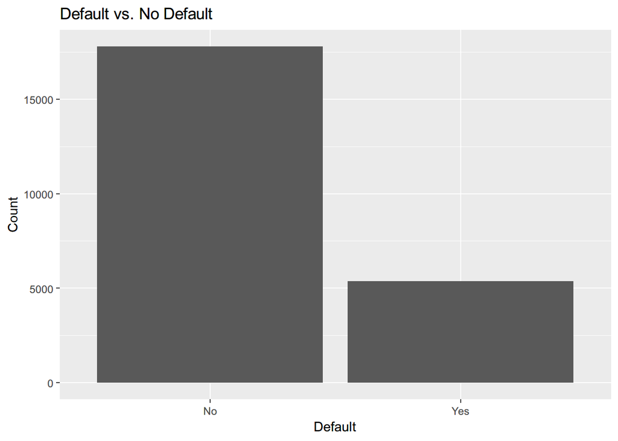

```r
ggplot(data, aes(x = default)) +
  geom_bar() +
  labs(title = "Default vs. No Default",
       x = "Default",
       y = "Count")
```

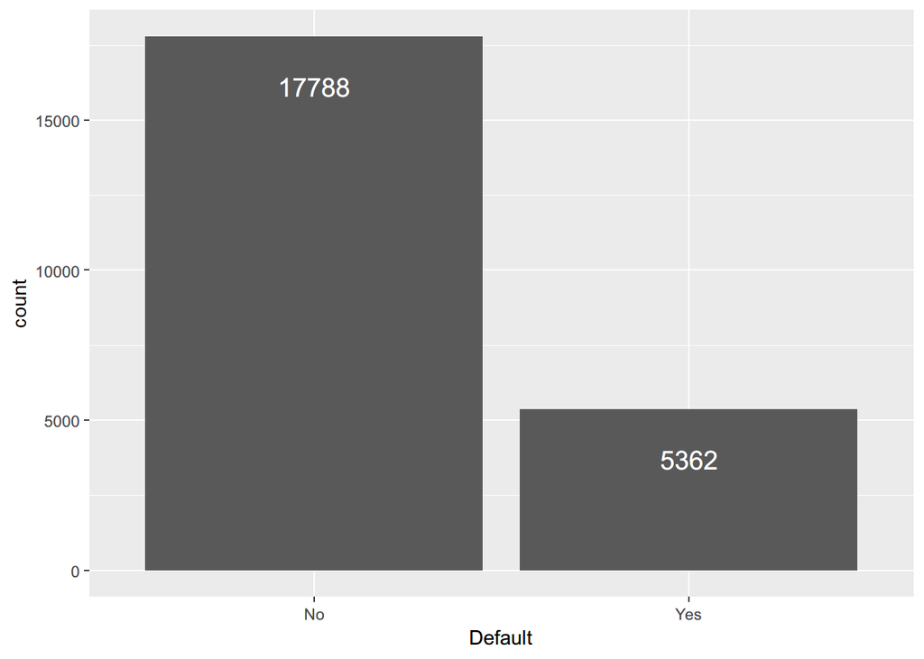

```r
ggplot(data, aes(x=default)) + geom_bar() +
  geom_text(stat="count",aes(label=..count..),vjust=3, color=I("white"),size=5) +
  labs(x="Default")
```

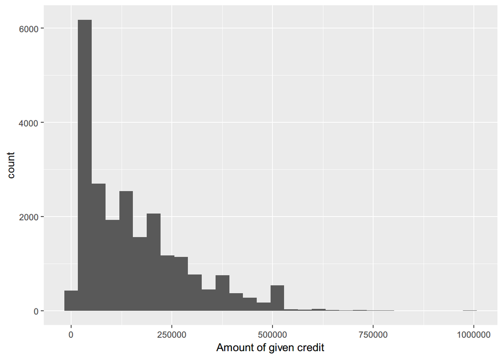

```r
ggplot(data, aes(x=LIMIT_BAL)) + geom_histogram() +
  labs(x="Amount of given credit")
```

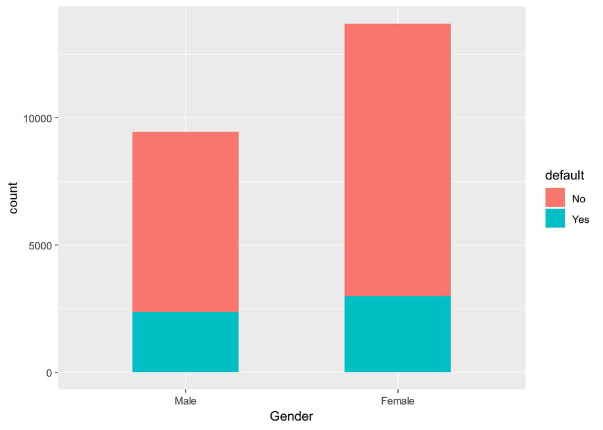

```r
# Create the bar chart with default and sex variables
ggplot(data, aes(x=SEX,fill = default), stat='bin' ) +
  geom_bar(width = 0.5) + labs(x = "Gender")
```

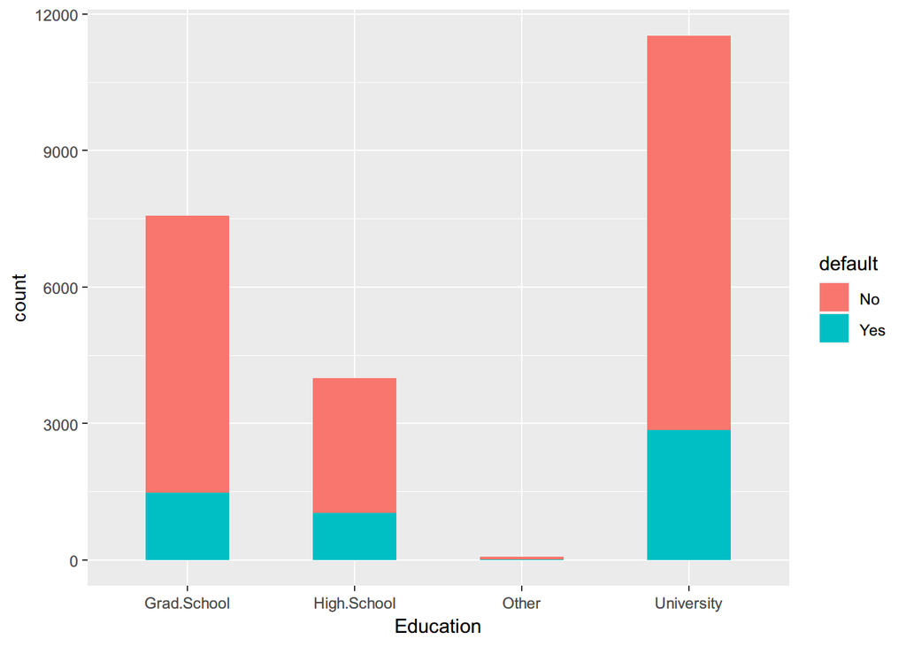

```r
ggplot(data, aes(x=EDUCATION,fill = default), stat='bin' ) +
  geom_bar(width = 0.5) + labs(x = "Education")
```

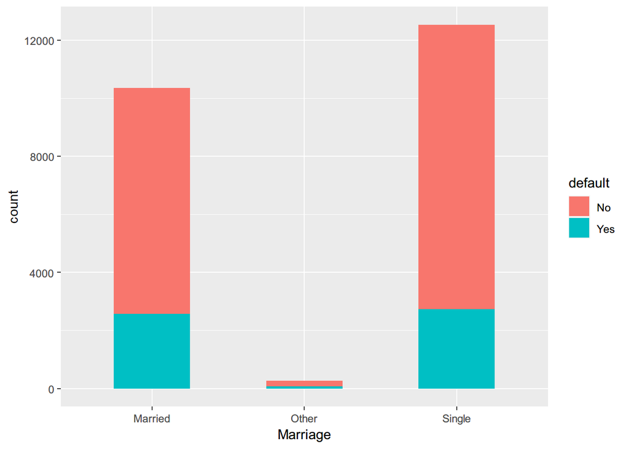

```r
ggplot(data, aes(x=MARRIAGE,fill = default), stat='bin' ) +
  geom_bar(width = 0.5) + labs(x = "Marriage")
```

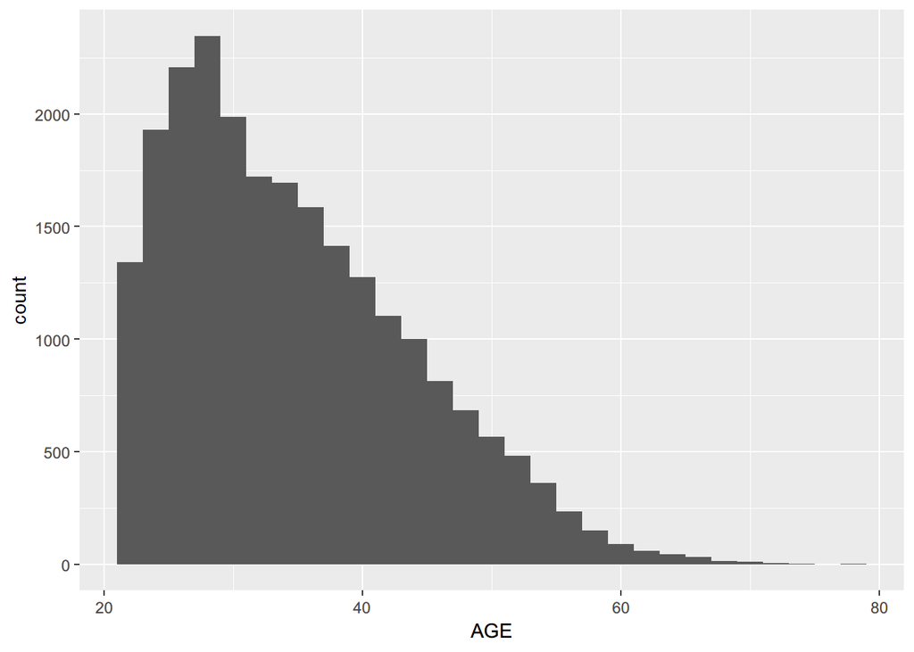

```r
ggplot(data, aes(x=AGE)) + geom_histogram()
```

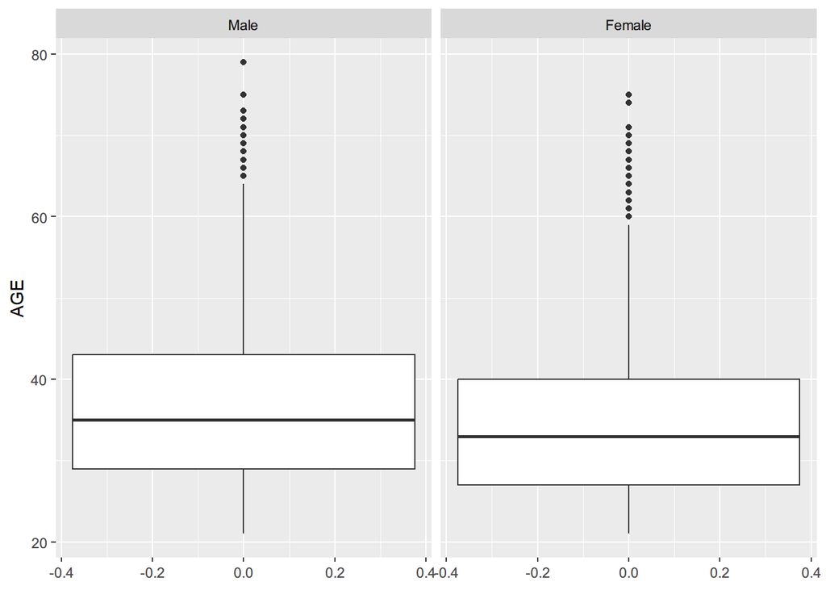

```r
ggplot(data, aes(y=AGE)) + geom_boxplot() + facet_wrap( ~ SEX)
```

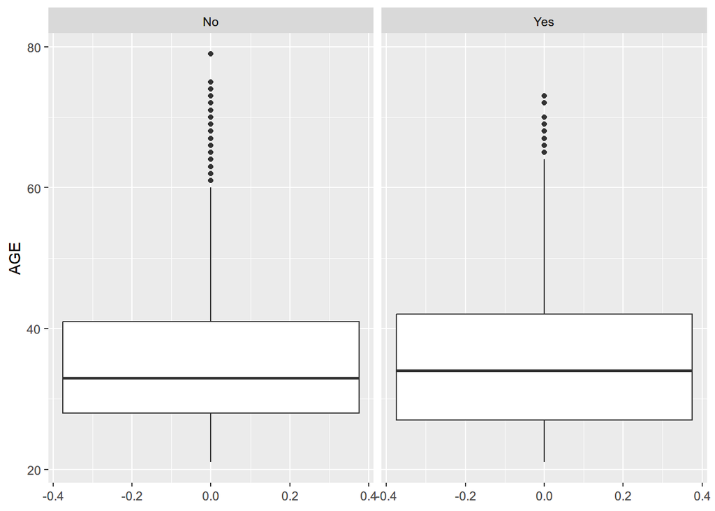

```r
ggplot(data, aes(y=AGE)) + geom_boxplot() + facet_wrap( ~ default)
```

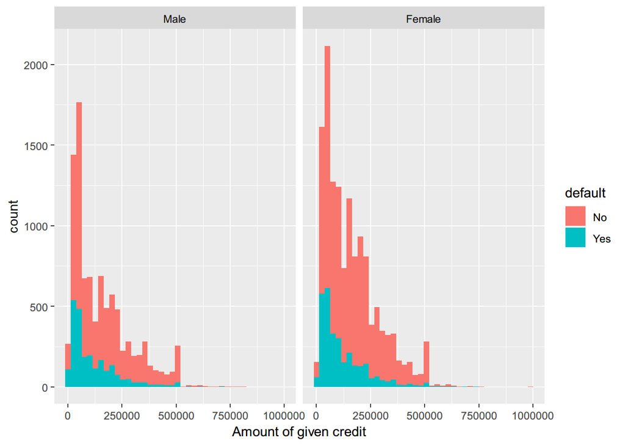

```r
ggplot(data, aes(x=LIMIT_BAL,fill=default)) + geom_histogram(bins = 40) + facet_wrap( ~ SEX) +
  labs(x="Amount of given credit")
```

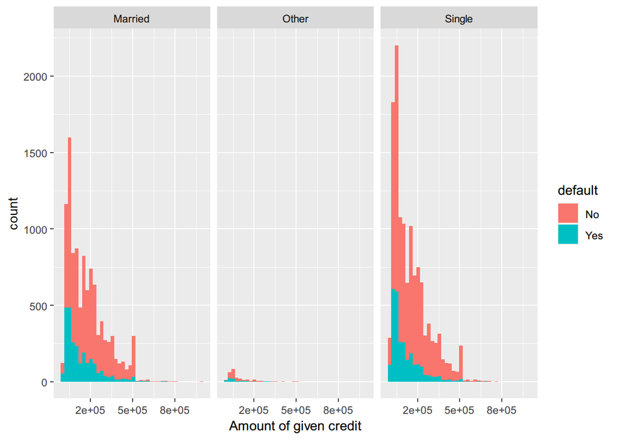

```r
ggplot(data, aes(x=LIMIT_BAL,fill=default)) + geom_histogram(bins = 40) + facet_wrap( ~ MARRIAGE) +
  labs(x="Amount of given credit") +
  scale_x_continuous(breaks = c(200000,500000,800000))
```

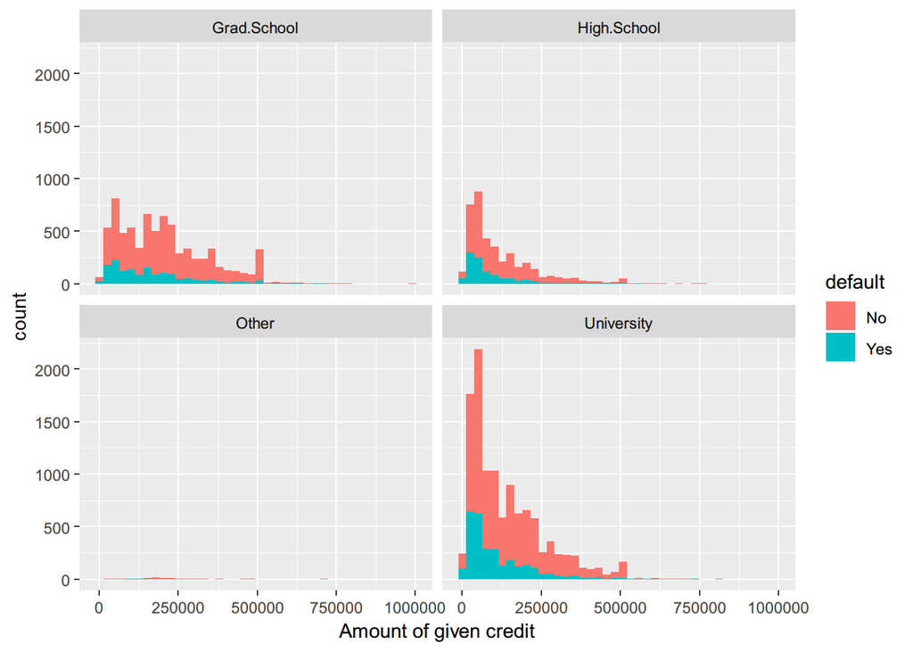

```r
ggplot(data, aes(x=LIMIT_BAL,fill=default)) + geom_histogram(bins = 40) + facet_wrap( ~ EDUCATION) +
  labs(x="Amount of given credit")
```

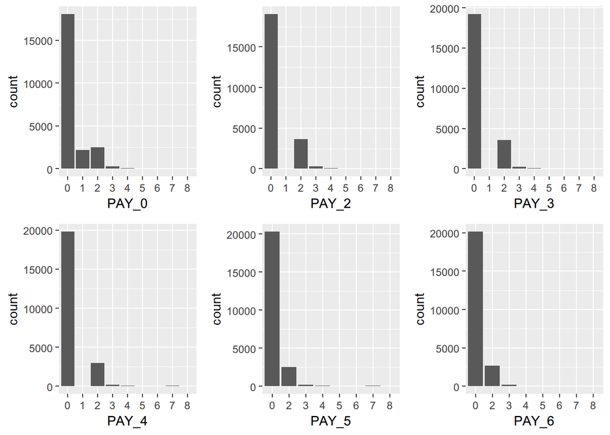

```r
#pay
pay_0 = ggplot(data, aes(x=PAY_0)) + geom_bar()
pay_2 = ggplot(data, aes(x=PAY_2)) + geom_bar()
pay_3 = ggplot(data, aes(x=PAY_3)) + geom_bar()
pay_4 = ggplot(data, aes(x=PAY_4)) + geom_bar()
pay_5 = ggplot(data, aes(x=PAY_5)) + geom_bar()
pay_6 = ggplot(data, aes(x=PAY_6)) + geom_bar()

grid.arrange(arrangeGrob(pay_0 + theme(legend.position = "none"),
                         pay_2 + theme(legend.position = "none"),
                         pay_3 + theme(legend.position = "none"),
                         pay_4 + theme(legend.position = "none"),
                         pay_5 + theme(legend.position = "none"),
                         pay_6 + theme(legend.position = "none"), nrow = 2))
```

```r
# No delay payment
df_no_delay = data %>%
  filter(PAY_0 ==0 & PAY_2 ==0 & PAY_3 ==0 & PAY_4 ==0 & PAY_5 ==0 & PAY_6 ==0)
table(df_no_delay$default)[2]/nrow(df_no_delay) # default rate
```

```
##       Yes
## 0.1121954
```

```r
# Delay payment for all months
df_delay = data %>%
  filter(PAY_0 != 0 & PAY_2 != 0 & PAY_3 != 0 & PAY_4 != 0 & PAY_5 != 0 & PAY_6 != 0 ) ->data_not0
table(df_delay$default)[2]/nrow(df_delay) # default rate
```

```
##       Yes
## 0.7061469
```